# HW2 - Exercise 3 (Covid-19)

MATH 345-545

Spring 2022

## Question 1

Import the data:

```r
covid <- read.table("world-covid-2022-02-04.txt", header = TRUE)
```

Note: the argument `header = TRUE` tells R that the first line of the data file contains the variables' names -not data.

Attach the data frame for easier manipulation:

```r
attach(covid)
```

## Question 2

Number of rows (cases) and columns (variables) in dataset:

```r
dim(covid)
```

```
## [1] 225  14
```

```r
str(covid) # to get information on variable names and types
```

```
## 'data.frame':    225 obs. of  14 variables:
##  $ Country          : chr  "USA" "India" "Brazil" "France" ...
##  $ Total.Cases      : int  77150412 41952712 26099735 20147341 17689885 12452765 11940695 11449601 10599244 10199716 ...
##  $ New.Cases        : num  NA NA NA NA 84.1 ...
##  $ Total.Deaths     : num  921 500 630 132 158 ...
##  $ New.Deaths       : int  NA NA NA NA 254 682 NA 433 26 NA ...
##  $ Total.Recovered  : int  47313736 40017088 22602506 13437823 14977096 10449181 11173406 9083090 7953200 6480464 ...
##  $ New.Recovered    : int  NA NA NA NA 145655 58449 NA 210353 84000 NA ...
##  $ Active.Cases     : int  28915847 1435537 2867228 6577666 2554805 1669545 679225 2218344 2526949 3625212 ...
##  $ Serious..Critical: num  21.64 8.94 8.32 3.64 478 ...
##  $ Tot.Cases.1M.pop : num  230.9 29.9 121.4 307.6 258.4 ...
##  $ Deaths.1M.pop    : num  2.76 357 2.93 2.01 2.31 ...
##  $ Total.Tests      : num  9.10e+08 7.36e+08 6.38e+07 2.32e+08 4.58e+08 ...
##  $ Tests.1M.pop     : int  2724296 524986 296687 3536455 6697523 1695496 1546631 2895261 1064272 1415323 ...
##  $ Population       : int  334088290 1401569003 214961303 65503153 68452931 146033957 85781430 60320461 84209874 46783572 ...
```

## Question 3

Plot population size (x axis) versus total number of cases (y axis):

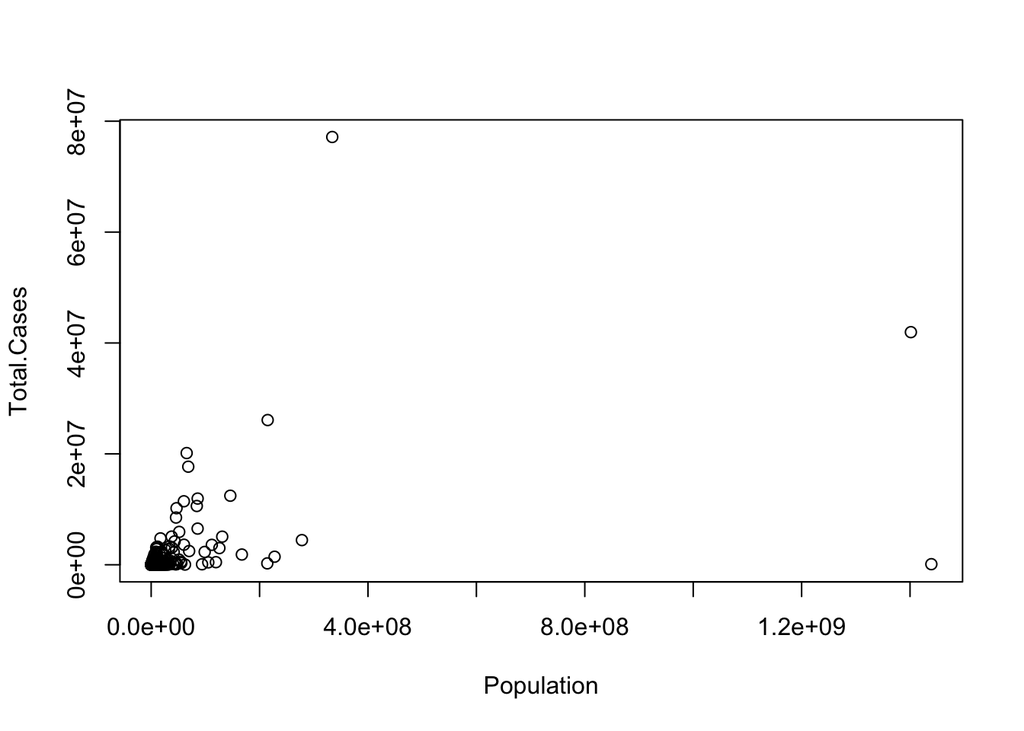

```r
plot(Population, Total.Cases)
```

Because of very large values, this scatter plot is a little difficult to interpret. Plot it again on a logarithmic scale:

```r
plot(Population, Total.Cases,  log = "xy")
## Add a regression line
reg <- lm(log(Total.Cases) ~ log(Population))
summary(reg)
```

```
##
## Call:
## lm(formula = log(Total.Cases) ~ log(Population))
##
## Residuals:
##     Min      1Q  Median      3Q     Max
## -8.7976 -1.2914  0.7599  1.5552  2.7845
##
## Coefficients:
##                 Estimate Std. Error t value Pr(>|t|)
## (Intercept)      -0.8587     0.8332  -1.031    0.304
## log(Population)   0.8275     0.0545  15.182   <2e-16 ***
## ---
## Signif. codes:  0 '***' 0.001 '**' 0.01 '*' 0.05 '.' 0.1 ' ' 1
##
## Residual standard error: 2.162 on 221 degrees of freedom
##   (2 observations deleted due to missingness)
## Multiple R-squared:  0.5105, Adjusted R-squared:  0.5083
## F-statistic: 230.5 on 1 and 221 DF,  p-value: < 2.2e-16
```

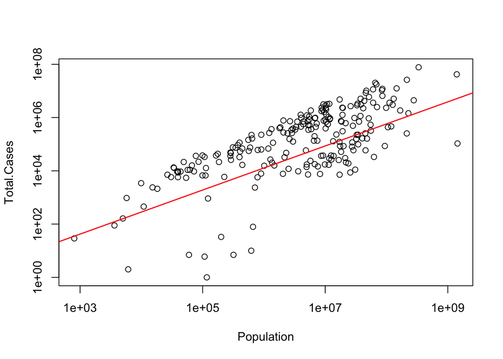

```r
abline(reg, col = "red", lwd = 1.5)
```

## Question 4

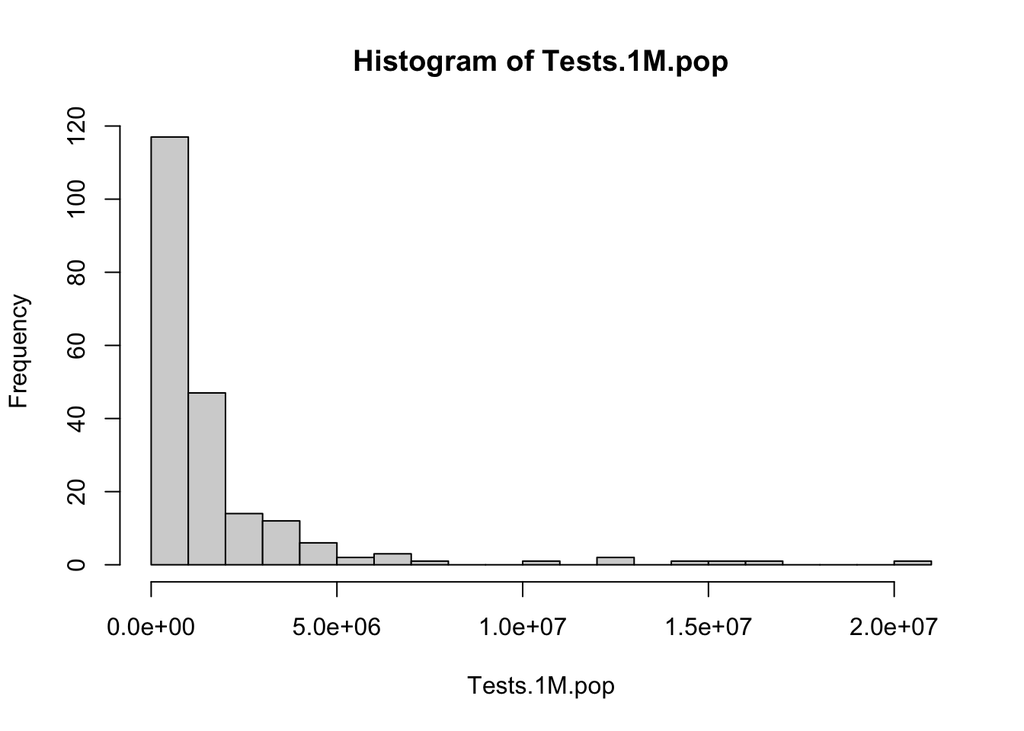

```r
hist(Tests.1M.pop, breaks = 20)
```

This histogram is skewed to the right (it has a long right tail). While most countries have under 5 millions tests per million people, some have over 20 million tests per million people.

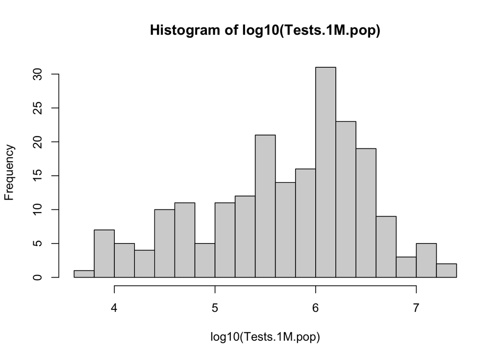

```r
hist(log10(Tests.1M.pop), breaks = 20)
```

This histogram shows the same data on a logarithmic scale base 10). As a result, it shows much more detail on the lower values (say, under 1M test per M people) which make up most of the data. Here, the histogram appears skewed to the left (long left tail, shorter right tail).

List the countries by increasing order of testing (not asked in the homework):

```r
o <- order(Tests.1M.pop)
data.frame(Country[o], Tests.1M.pop[o])
```

```
##                 Country.o. Tests.1M.pop.o.
## 1                  Algeria            5118
## 2                  Eritrea            6537
## 3          Solomon Islands            7170
## 4                    Macao            7864
## 5                    Syria            8048
## 6                    Niger            8507
## 7                    Yemen            8593
## 8                      DRC            9019
## 9                     Chad           11141
## 10            Burkina Faso           11201
## 11                   Haiti           11393
## 12                   Sudan           12379
## 13              Madagascar           12859
## 14                     CAR           16379
```

[output cut: 211 more lines]

## Question 5

Calculate the ratio of active cases over population size:

```r
r <- Active.Cases / Population
```

What is the largest value of this ratio?

```r
max(r) # does not work because of missing values
```

```
## [1] NA
```

```r
max(r, na.rm = TRUE) # this work but we don't which country this corresponds to
```

```
## [1] 0.2796086
```

Find the corresponding country:

```r
idx <- which.max(r)
Country[idx]
```

```
## [1] "Faeroe Islands"
```

In light of the fact that Denmark has the highest testing rate (question 4), it makes sense that the Faeroe Islands, an autonomous territory of Denmark, has the highest rate of active infections. This is because more testing implies more detection of the virus, all other things being equal.

Finally, don't forget to detach the data frame when you are done with your analysis:

```r
detach(covid)
```